# Many Kinds of Feature Importance

### Setup

We begin by defining a PMF presented in Devroye, Gyorfi, and Lugosi (1997) - Theorem 32.2. This theorem finds its roots in Toussaint (1971): "Note on Optimal Selection of Independent Binary-Valued Features for Pattern Recognition." Toussaint's note is based on Elashoff's 1967 paper "On the choice of variables in classification problems with dichotomous variables."

There exist binary-valued random variables $X_1$, $X_2$, $X_3$, $Y \in \{0, 1\}$ such that $X_1$, $X_2$, and $X_3$ are conditionally independent (given $Y$), and

$L^*(\{1\}) < L^*(\{2\}) < L^*(\{3\})$,

but

$L^*(\{1, 2\}) > L^*(\{1, 3\}) > L^*(\{2, 3\})$.

**PROOF.** Let $P(Y = 1) = 1/2$. Then the joint distribution of $X_1$, $X_2$, $X_3$, $Y$ is specified by the conditional probabilities $P(X_i = 1 \mid Y = 0)$ and $P(X_i = 1 \mid Y = 1)$, $i = 1, 2, 3$. Straightforward calculation shows that the values

$P(X_1 = 1 \mid Y = 0) = 0.1, P(X_1 = 1 \mid Y = 1) = 0.9,$

$P(X_2 = 1 \mid Y = 0) = 0.05, P(X_2 = 1 \mid Y = 1) = 0.8,$

$P(X_3 = 1 \mid Y = 0) = 0.01, P(X_3 = 1 \mid Y = 1) = 0.71$

satisfy the stated inequalities.

*Mike's Note:* It's worth observing the relationships between these three variables and $Y$. As you go from $X_1$ to $X_2$ to $X_3$, they become more useful for prediction when $Y=0$ (specificity). In contrast, they become more useful in reverse order ($X_3$ to $X_2$ to $X_1$) for prediction when $Y=1$ (sensitivity).

### Here's a twist: Add an uniformative $X_4$.

Now we have:

$P(X_1 = 1 \mid Y = 0) = 0.1, P(X_1 = 1 \mid Y = 1) = 0.9,$

$P(X_2 = 1 \mid Y = 0) = 0.05, P(X_2 = 1 \mid Y = 1) = 0.8,$

$P(X_3 = 1 \mid Y = 0) = 0.01, P(X_3 = 1 \mid Y = 1) = 0.71$

$P(X_4 = 1 \mid Y = 0) = 0.5, P(X_4 = 1 \mid Y = 1) = 0.5$

### "Straightforward Calculations"

We'd like to store the joint PMF as a data frame. In each row we'll store a possible outcome.

Example: [$X_1 = 0$, $X_2 = 0$, $X_3 = 0$, $X_4 = 0$, $Y = 0$, $P(\text{this row})] \implies [0, 0, 0, 0, 0, p]$

The conditional independence of the $X$ covariates given $Y$ allows us to obtain $p$ through simple multiplication:

$\begin{align} P(X_1, X_2, X_3, X_4, Y) = &P(X_1, X_2, X_3, X_4 | Y) \times P(Y) \\ = &P(X_1|Y) \times P(X_2|Y) \times P(X_3|Y) \times P(X_4|Y) \times P(Y) \end{align}$

Example:

$\begin{align} P(X_1 = 0, X_2 = 0, X_3 = 0, X_4 = 0, Y = 0) = &P(X_1=0|Y=0) \; \times\\ &P(X_2=0|Y=0) \; \times\\ &P(X_3=0|Y=0) \; \times\\ &P(X_4=0|Y=0) \; \times\\ &P(Y = 0) \end{align}$

We have all such conditional probabilities (or their complements) specified in the problem statement.

```python
import numpy as np
import pandas as pd
from scipy.stats import entropy
```

```python
# In the following, P(Xj=x|Y=y) is accessed with p_xj_y[y,x].
p_x1_y = np.array([[.9, .1], [.1, .9]])
p_x2_y = np.array([[.95, .05], [.2, .8]])
p_x3_y = np.array([[.99, .01], [.29, .71]])
p_x4_y = np.array([[.5, .5], [.5, .5]])
p_y = np.array([.5, .5])

pmf = np.ones((2**5,6)) * -1

pmf_idx = 0
for x1 in [0,1]:
    for x2 in [0,1]:
        for x3 in [0,1]:
            for x4 in [0,1]:
                for y in [0,1]:
                    p = p_x1_y[y, x1] * p_x2_y[y, x2] * p_x3_y[y, x3] * p_x4_y[y, x4] * p_y[y]
                    pmf[pmf_idx, :] = np.array([x1, x2, x3, x4, y, p])
                    pmf_idx += 1

pmf = pd.DataFrame(pmf)
pmf.columns = ["X1", "X2", "X3", "X4", "Y", "p"]
pmf
```

|  | X1 | X2 | X3 | X4 | Y | p |
| --- | --- | --- | --- | --- | --- | --- |
| 0 | 0.0 | 0.0 | 0.0 | 0.0 | 0.0 | 0.211612 |
| 1 | 0.0 | 0.0 | 0.0 | 0.0 | 1.0 | 0.001450 |
| 2 | 0.0 | 0.0 | 0.0 | 1.0 | 0.0 | 0.211612 |
| 3 | 0.0 | 0.0 | 0.0 | 1.0 | 1.0 | 0.001450 |
| 4 | 0.0 | 0.0 | 1.0 | 0.0 | 0.0 | 0.002138 |
| 5 | 0.0 | 0.0 | 1.0 | 0.0 | 1.0 | 0.003550 |
| 6 | 0.0 | 0.0 | 1.0 | 1.0 | 0.0 | 0.002138 |
| 7 | 0.0 | 0.0 | 1.0 | 1.0 | 1.0 | 0.003550 |
| 8 | 0.0 | 1.0 | 0.0 | 0.0 | 0.0 | 0.011138 |
| 9 | 0.0 | 1.0 | 0.0 | 0.0 | 1.0 | 0.005800 |
| 10 | 0.0 | 1.0 | 0.0 | 1.0 | 0.0 | 0.011138 |
| 11 | 0.0 | 1.0 | 0.0 | 1.0 | 1.0 | 0.005800 |
| 12 | 0.0 | 1.0 | 1.0 | 0.0 | 0.0 | 0.000113 |
| 13 | 0.0 | 1.0 | 1.0 | 0.0 | 1.0 | 0.014200 |
| 14 | 0.0 | 1.0 | 1.0 | 1.0 | 0.0 | 0.000113 |
| 15 | 0.0 | 1.0 | 1.0 | 1.0 | 1.0 | 0.014200 |
| 16 | 1.0 | 0.0 | 0.0 | 0.0 | 0.0 | 0.023512 |
| 17 | 1.0 | 0.0 | 0.0 | 0.0 | 1.0 | 0.013050 |
| 18 | 1.0 | 0.0 | 0.0 | 1.0 | 0.0 | 0.023512 |
| 19 | 1.0 | 0.0 | 0.0 | 1.0 | 1.0 | 0.013050 |
| 20 | 1.0 | 0.0 | 1.0 | 0.0 | 0.0 | 0.000237 |
| 21 | 1.0 | 0.0 | 1.0 | 0.0 | 1.0 | 0.031950 |
| 22 | 1.0 | 0.0 | 1.0 | 1.0 | 0.0 | 0.000237 |
| 23 | 1.0 | 0.0 | 1.0 | 1.0 | 1.0 | 0.031950 |
| 24 | 1.0 | 1.0 | 0.0 | 0.0 | 0.0 | 0.001238 |
| 25 | 1.0 | 1.0 | 0.0 | 0.0 | 1.0 | 0.052200 |
| 26 | 1.0 | 1.0 | 0.0 | 1.0 | 0.0 | 0.001238 |
| 27 | 1.0 | 1.0 | 0.0 | 1.0 | 1.0 | 0.052200 |
| 28 | 1.0 | 1.0 | 1.0 | 0.0 | 0.0 | 0.000013 |
| 29 | 1.0 | 1.0 | 1.0 | 0.0 | 1.0 | 0.127800 |
| 30 | 1.0 | 1.0 | 1.0 | 1.0 | 0.0 | 0.000013 |
| 31 | 1.0 | 1.0 | 1.0 | 1.0 | 1.0 | 0.127800 |

```python
# Valid PMF? Yep.
pmf['p'].sum()
```

```
0.9999999999999999
```

### Function Definitions

We're going to need a few functions that perform probability calculations.

- Compute Probability of Event from PMF
- Conditional Probability
- Conditional Entropy

```python
# Obtain Probability (any unconditioned event)
def prob(pmf, event):
    # Sum all the p values that correspond to rows satisfying the "event" constraint.
    return pmf[(pmf[list(event.keys())] == pd.Series(event)).all(axis=1)].loc[:,"p"].sum()

# Conditional Probability
def cond_prob(pmf, event, given):
    # Filter the PMF to retain only the rows that satisfy the "given" constraint.
    given_pmf = pmf[(pmf[list(given.keys())] == pd.Series(given)).all(axis=1)]
    # Sum all the p values that correspond to rows satisfying the "given" constraint.
    given_mass = given_pmf.loc[:,"p"].sum()
    # Within the filtered "given" PMF (potentially reduced total rows), sum all the
    # p values that correspond to rows satisfying the "event" constraint.  This is
    # the intersection of the "event" and "given" constraints.
    event_mass = given_pmf[(given_pmf[list(event.keys())] == pd.Series(event)).all(axis=1)].loc[:,"p"].sum()
    # Return ("event" AND "given" / "given")
    return event_mass / given_mass

# Entropy
# (Note: Takes care of both class 0 and 1.)
# The entropy function takes an array of probabilities and computes
# sum[p log p].
def reg_entropy(pmf, event):
    this_prob = prob(pmf, event)
    return entropy([this_prob, 1 - this_prob], base=2)

# Conditional Entropy
# (Note: Takes care of both class 0 and 1.  Supply either event.)
def cond_entropy(pmf, event, given):
    this_cond_prob = cond_prob(pmf, event, given)
    return entropy([this_cond_prob, 1 - this_cond_prob], base=2)
```

### Example Function Usage

```python
# Extract a probability from the PMF.
# Example: Obtain the probability of the first row outcome in the PMF.
event = {'X1': 0.0,
         'X2': 0.0,
         'X3': 0.0,
         'X4': 0.0,
         'Y': 0.0}
prob(pmf, event)
```

```
0.21161249999999998
```

```python
# Conditional Probability
# Example: Find P(Y=0|X1=0,X2=0,X3=0)
event = {'Y': 0.0}
given = {'X1': 0.0,
         'X2': 0.0,
         'X3': 0.0,
         'X4': 0.0}
cond_prob(pmf, event, given)
```

```
0.9931944851862716
```

```python
# Entropy
# Example: Find H(Y)
event = {'Y': 0.0}
reg_entropy(pmf, event)
```

```
1.0
```

```python
# Conditional Entropy
# Example: Find H(Y|X1=0,X2=0,X3=0)
event = {'Y': 0.0}
given = {'X1': 0.0,
         'X2': 0.0,
         'X3': 0.0,
         'X4': 0.0}
cond_entropy(pmf, event, given)
```

```
0.0587782426667411
```

### Computing Loss - Best Single Feature

Below we'll find that single-feature classifier performance would rank features in this order: $X_1$, $X_2$, $X_3$, $X_4$.

```python
# Feature 1

# P(Y=0|X1)
p_y_0_x1 = np.zeros(2)
for x1 in [0,1]:
    event = {'Y': 0.0}
    given = {'X1': x1}
    p_y_0_x1[x1] = cond_prob(pmf, event, given)

# P(Y=1|X1)
p_y_1_x1 = np.zeros(2)
for x1 in [0,1]:
    event = {'Y': 1.0}
    given = {'X1': x1}
    p_y_1_x1[x1] = cond_prob(pmf, event, given)

# P(X1)
p_x1 = np.zeros(2)
for x1 in [0,1]:
    event = {'X1': x1}
    p_x1[x1] = prob(pmf, event)

# Which to choose?
p_correct_x1 = np.sum(np.maximum(p_y_0_x1, p_y_1_x1) * p_x1)
print(f"Feature 1 Loss: {(1 - p_correct_x1):.5f}")
```

```
Feature 1 Loss: 0.10000
```

```python
# Feature 2

# P(Y=0|X2)
p_y_0_x2 = np.zeros(2)
for x2 in [0,1]:
    event = {'Y': 0.0}
    given = {'X2': x2}
    p_y_0_x2[x2] = cond_prob(pmf, event, given)

# P(Y=1|X2)
p_y_1_x2 = np.zeros(2)
for x2 in [0,1]:
    event = {'Y': 1.0}
    given = {'X2': x2}
    p_y_1_x2[x2] = cond_prob(pmf, event, given)

# P(X2)
p_x2 = np.zeros(2)
for x2 in [0,1]:
    event = {'X2': x2}
    p_x2[x2] = prob(pmf, event)

# Which to choose?
p_correct_x2 = np.sum(np.maximum(p_y_0_x2, p_y_1_x2) * p_x2)
print(f"Feature 2 Loss: {(1 - p_correct_x2):.5f}")
```

```
Feature 2 Loss: 0.12500
```

```python
# Feature 3

# P(Y=0|X3)
p_y_0_x3 = np.zeros(2)
for x3 in [0,1]:
    event = {'Y': 0.0}
    given = {'X3': x3}
    p_y_0_x3[x3] = cond_prob(pmf, event, given)

# P(Y=1|X3)
p_y_1_x3 = np.zeros(2)
for x3 in [0,1]:
    event = {'Y': 1.0}
    given = {'X3': x3}
    p_y_1_x3[x3] = cond_prob(pmf, event, given)

# P(X3)
p_x3 = np.zeros(2)
for x3 in [0,1]:
    event = {'X3': x3}
    p_x3[x3] = prob(pmf, event)

# Which to choose?
p_correct_x3 = np.sum(np.maximum(p_y_0_x3, p_y_1_x3) * p_x3)
print(f"Feature 3 Loss: {(1 - p_correct_x3):.5f}")
```

```
Feature 3 Loss: 0.15000
```

```python
# Feature 4
# As expected, an uninformative feature does no better than
# the base rate P(Y=1)=.5

# P(Y=0|X4)
p_y_0_x4 = np.zeros(2)
for x4 in [0,1]:
    event = {'Y': 0.0}
    given = {'X4': x4}
    p_y_0_x4[x4] = cond_prob(pmf, event, given)

# P(Y=1|X4)
p_y_1_x4 = np.zeros(2)
for x4 in [0,1]:
    event = {'Y': 1.0}
    given = {'X4': x4}
    p_y_1_x4[x4] = cond_prob(pmf, event, given)

# P(X4)
p_x4 = np.zeros(2)
for x4 in [0,1]:
    event = {'X4': x4}
    p_x4[x4] = prob(pmf, event)

# Which to choose?
p_correct_x4 = np.sum(np.maximum(p_y_0_x4, p_y_1_x4) * p_x4)
print(f"Feature 4 Loss: {(1 - p_correct_x4):.5f}")
```

```
Feature 4 Loss: 0.50000
```

### Computing Loss - Best Two Features

Below we'll find that two-feature classifier performance would rank features in this order: $\{X_2,X_3\}$, $\{X_1,X_3\}$, $\{X_1,X_2\}$, $\{X_1,X_4\}$, $\{X_2,X_4\}$, $\{X_3,X_4\}$. This is surprising because the best single feature isn't part of the best two-feature classifier! Interestingly, the decision rule is the same for the three best two-feature classifiers: if at least one covariate in $\{X_1,X_2,X_3\}$ equals 1, predict class 1.

We need to compute a few probability matrices. $P(Y = 0|X_1,X_2)$ for $X_1 \in \{0,1\}, X_2 \in \{0,1\}$ and $P(Y = 1|X_1,X_2)$ for $X_1 \in \{0,1\}, X_2 \in \{0,1\}$.

```python
# Features 1 and 2

# P(Y=0|X1,X2)
p_y_0_x1_x2 = np.zeros((2,2))
for x1 in [0,1]:
    for x2 in [0,1]:
        event = {'Y': 0.0}
        given = {'X1': x1,
                 'X2': x2}
        p_y_0_x1_x2[x1,x2] = cond_prob(pmf, event, given)

# P(Y=1|X1,X2)
p_y_1_x1_x2 = np.zeros((2,2))
for x1 in [0,1]:
    for x2 in [0,1]:
        event = {'Y': 1.0}
        given = {'X1': x1,
                 'X2': x2}
        p_y_1_x1_x2[x1,x2] = cond_prob(pmf, event, given)

# P(X1,X2)
p_x1_x2 = np.zeros((2,2))
for x1 in [0,1]:
    for x2 in [0,1]:
        event = {'X1': x1,
                 'X2': x2}
        p_x1_x2[x1,x2] = prob(pmf, event)

# Which to choose?
print("For X1 (rows) x X2 (columns) with {0,0} top left, predict as follows:")
print((p_y_1_x1_x2 > p_y_0_x1_x2).astype(int))
p_correct_x1_x2 = np.sum(np.maximum(p_y_0_x1_x2, p_y_1_x1_x2) * p_x1_x2)
print(f"Features 1 & 2 Loss: {(1 - p_correct_x1_x2):.5f}")
```

```
For X1 (rows) x X2 (columns) with {0,0} top left, predict as follows:
[[0 1]
 [1 1]]
Features 1 & 2 Loss: 0.08250
```

```python
# Features 1 and 3

# P(Y=0|X1,X3)
p_y_0_x1_x3 = np.zeros((2,2))
for x1 in [0,1]:
    for x3 in [0,1]:
        event = {'Y': 0.0}
        given = {'X1': x1,
                 'X3': x3}
        p_y_0_x1_x3[x1,x3] = cond_prob(pmf, event, given)

# P(Y=1|X1,X3)
p_y_1_x1_x3 = np.zeros((2,2))
for x1 in [0,1]:
    for x3 in [0,1]:
        event = {'Y': 1.0}
        given = {'X1': x1,
                 'X3': x3}
        p_y_1_x1_x3[x1,x3] = cond_prob(pmf, event, given)

# P(X1,X3)
p_x1_x3 = np.zeros((2,2))
for x1 in [0,1]:
    for x3 in [0,1]:
        event = {'X1': x1,
                 'X3': x3}
        p_x1_x3[x1,x3] = prob(pmf, event)

# Which to choose?
print("For X1 (rows) x X3 (columns) with {0,0} top left, predict as follows:")
print((p_y_1_x1_x3 > p_y_0_x1_x3).astype(int))
p_correct_x1_x3 = np.sum(np.maximum(p_y_0_x1_x3, p_y_1_x1_x3) * p_x1_x3)
print(f"Features 1 & 3 Loss: {(1 - p_correct_x1_x3):.5f}")
```

```
For X1 (rows) x X3 (columns) with {0,0} top left, predict as follows:
[[0 1]
 [1 1]]
Features 1 & 3 Loss: 0.06900
```

```python
# Features 2 and 3

# P(Y=0|X2,X3)
p_y_0_x2_x3 = np.zeros((2,2))
for x2 in [0,1]:
    for x3 in [0,1]:
        event = {'Y': 0.0}
        given = {'X2': x2,
                 'X3': x3}
        p_y_0_x2_x3[x2,x3] = cond_prob(pmf, event, given)

# P(Y=1|X2,X3)
p_y_1_x2_x3 = np.zeros((2,2))
for x2 in [0,1]:
    for x3 in [0,1]:
        event = {'Y': 1.0}
        given = {'X2': x2,
                 'X3': x3}
        p_y_1_x2_x3[x2,x3] = cond_prob(pmf, event, given)

# P(X2,X3)
p_x2_x3 = np.zeros((2,2))
for x2 in [0,1]:
    for x3 in [0,1]:
        event = {'X2': x2,
                 'X3': x3}
        p_x2_x3[x2,x3] = prob(pmf, event)

# Which to choose?
print("For X2 (rows) x X3 (columns) with {0,0} top left, predict as follows:")
print((p_y_1_x2_x3 > p_y_0_x2_x3).astype(int))
p_correct_x2_x3 = np.sum(np.maximum(p_y_0_x2_x3, p_y_1_x2_x3) * p_x2_x3)
print(f"Features 2 & 3 Loss: {(1 - p_correct_x2_x3):.5f}")
```

```
For X2 (rows) x X3 (columns) with {0,0} top left, predict as follows:
[[0 1]
 [1 1]]
Features 2 & 3 Loss: 0.05875
```

Note: All calculations above exactly match the results of Toussaint's 1971 note.

```python
# Features 1 and 4

# P(Y=0|X1,X4)
p_y_0_x1_x4 = np.zeros((2,2))
for x1 in [0,1]:
    for x4 in [0,1]:
        event = {'Y': 0.0}
        given = {'X1': x1,
                 'X4': x4}
        p_y_0_x1_x4[x1,x4] = cond_prob(pmf, event, given)

# P(Y=1|X1,X4)
p_y_1_x1_x4 = np.zeros((2,2))
for x1 in [0,1]:
    for x4 in [0,1]:
        event = {'Y': 1.0}
        given = {'X1': x1,
                 'X4': x4}
        p_y_1_x1_x4[x1,x4] = cond_prob(pmf, event, given)

# P(X1,X4)
p_x1_x4 = np.zeros((2,2))
for x1 in [0,1]:
    for x4 in [0,1]:
        event = {'X1': x1,
                 'X4': x4}
        p_x1_x4[x1,x4] = prob(pmf, event)

# Which to choose?
print("For X1 (rows) x X4 (columns) with {0,0} top left, predict as follows:")
print((p_y_1_x1_x4 > p_y_0_x1_x4).astype(int))
p_correct_x1_x4 = np.sum(np.maximum(p_y_0_x1_x4, p_y_1_x1_x4) * p_x1_x4)
print(f"Features 1 & 4 Loss: {(1 - p_correct_x1_x4):.5f}")
```

```
For X1 (rows) x X4 (columns) with {0,0} top left, predict as follows:
[[0 0]
 [1 1]]
Features 1 & 4 Loss: 0.10000
```

```python
# Features 2 and 4

# P(Y=0|X2,X4)
p_y_0_x2_x4 = np.zeros((2,2))
for x2 in [0,1]:
    for x4 in [0,1]:
        event = {'Y': 0.0}
        given = {'X2': x2,
                 'X4': x4}
        p_y_0_x2_x4[x2,x4] = cond_prob(pmf, event, given)

# P(Y=1|X2,X4)
p_y_1_x2_x4 = np.zeros((2,2))
for x2 in [0,1]:
    for x4 in [0,1]:
        event = {'Y': 1.0}
        given = {'X2': x2,
                 'X4': x4}
        p_y_1_x2_x4[x2,x4] = cond_prob(pmf, event, given)

# P(X2,X4)
p_x2_x4 = np.zeros((2,2))
for x2 in [0,1]:
    for x4 in [0,1]:
        event = {'X2': x2,
                 'X4': x4}
        p_x2_x4[x2,x4] = prob(pmf, event)

# Which to choose?
print("For X2 (rows) x X4 (columns) with {0,0} top left, predict as follows:")
print((p_y_1_x2_x4 > p_y_0_x2_x4).astype(int))
p_correct_x2_x4 = np.sum(np.maximum(p_y_0_x2_x4, p_y_1_x2_x4) * p_x2_x4)
print(f"Features 2 & 4 Loss: {(1 - p_correct_x2_x4):.5f}")
```

```
For X2 (rows) x X4 (columns) with {0,0} top left, predict as follows:
[[0 0]
 [1 1]]
Features 2 & 4 Loss: 0.12500
```

```python
# Features 3 and 4

# P(Y=0|X3,X4)
p_y_0_x3_x4 = np.zeros((2,2))
for x3 in [0,1]:
    for x4 in [0,1]:
        event = {'Y': 0.0}
        given = {'X3': x3,
                 'X4': x4}
        p_y_0_x3_x4[x3,x4] = cond_prob(pmf, event, given)

# P(Y=1|X3,X4)
p_y_1_x3_x4 = np.zeros((2,2))
for x3 in [0,1]:
    for x4 in [0,1]:
        event = {'Y': 1.0}
        given = {'X3': x3,
                 'X4': x4}
        p_y_1_x3_x4[x3,x4] = cond_prob(pmf, event, given)

# P(X3,X4)
p_x3_x4 = np.zeros((2,2))
for x3 in [0,1]:
    for x4 in [0,1]:
        event = {'X3': x3,
                 'X4': x4}
        p_x3_x4[x3,x4] = prob(pmf, event)

# Which to choose?
print("For X3 (rows) x X4 (columns) with {0,0} top left, predict as follows:")
print((p_y_1_x3_x4 > p_y_0_x3_x4).astype(int))
p_correct_x3_x4 = np.sum(np.maximum(p_y_0_x3_x4, p_y_1_x3_x4) * p_x3_x4)
print(f"Features 3 & 4 Loss: {(1 - p_correct_x3_x4):.5f}")
```

```
For X3 (rows) x X4 (columns) with {0,0} top left, predict as follows:
[[0 0]
 [1 1]]
Features 3 & 4 Loss: 0.15000
```

Note: It makes sense that combining the uninformative $X^{(4)}$ with any informative feature would result in the same expected loss that the single informative feature would yield on its own.

### Conditional Entropy

Now we want to examine the various feature combinations in terms of how much uncertainty in $Y$ remains given a set of features in $X$. Conditional entropy averages across all values of $X=x$ (according to their density) the residual uncertainty of $Y$ after knowing $X$.

Conditional Entropy: $H(Y|X) = \sum_{X=x}p(x)\big[-\sum_{Y=y}p(y|x)\log(p(y|x))\big]$

### Conditional Entropy - One Feature

Below we'll find that one-feature conditional entropy would rank features in this order (smallest to largest): $X_1$, $X_2$, $X_3$, $X_4$.

```python
# Feature 1

# H(Y|X1)
h_y_x1 = np.zeros(2)
for x1 in [0,1]:
    event = {'Y': 0.0}
    given = {'X1': x1}
    h_y_x1[x1] = cond_entropy(pmf, event, given)

p_x1 = np.zeros(2)
for x1 in [0,1]:
    event = {'X1': x1}
    p_x1[x1] = prob(pmf, event)

# Compute conditional entropy.
ce_x1 = np.sum(p_x1 * h_y_x1)
print(f"Feature 1 Conditional Entropy: {(ce_x1):.5f}")
```

```
Feature 1 Conditional Entropy: 0.46900
```

```python
# Feature 2

# H(Y|X2)
h_y_x2 = np.zeros(2)
for x2 in [0,1]:
    event = {'Y': 0.0}
    given = {'X2': x2}
    h_y_x2[x2] = cond_entropy(pmf, event, given)

# P(X2)
p_x2 = np.zeros(2)
for x2 in [0,1]:
    event = {'X2': x2}
    p_x2[x2] = prob(pmf, event)

# Compute conditional entropy.
ce_x2 = np.sum(p_x2 * h_y_x2)
print(f"Feature 2 Conditional Entropy: {(ce_x2):.5f}")
```

```
Feature 2 Conditional Entropy: 0.52045
```

```python
# Feature 3

# H(Y=0|X3)
h_y_x3 = np.zeros(2)
for x3 in [0,1]:
    event = {'Y': 0.0}
    given = {'X3': x3}
    h_y_x3[x3] = cond_entropy(pmf, event, given)

# P(X3)
p_x3 = np.zeros(2)
for x3 in [0,1]:
    event = {'X3': x3}
    p_x3[x3] = prob(pmf, event)

# Compute conditional entropy.
ce_x3 = np.sum(p_x3 * h_y_x3)
print(f"Feature 3 Conditional Entropy: {(ce_x3):.5f}")
```

```
Feature 3 Conditional Entropy: 0.53207
```

```python
# Feature 4

# H(Y=0|X4)
h_y_x4 = np.zeros(2)
for x4 in [0,1]:
    event = {'Y': 0.0}
    given = {'X4': x4}
    h_y_x4[x4] = cond_entropy(pmf, event, given)

# P(X4)
p_x4 = np.zeros(2)
for x4 in [0,1]:
    event = {'X4': x4}
    p_x4[x4] = prob(pmf, event)

# Compute conditional entropy.
ce_x4 = np.sum(p_x4 * h_y_x4)
print(f"Feature 4 Conditional Entropy: {(ce_x4):.5f}")
```

```
Feature 4 Conditional Entropy: 1.00000
```

### Conditional Entropy - Two Features

Below we'll find that two-feature classifier performance measured by conditional entropy would rank features in this order: $\{X_1,X_3\}$, $\{X_1,X_2\}$, $\{X_2,X_3\}$, $\{X_1,X_4\}$, $\{X_2,X_4\}$, $\{X_3,X_4\}$. Unfortunately, this moves our previous winner to third place.

```python
# Features 1 and 2

# H(Y|X1,X2)
h_y_x1_x2 = np.zeros((2,2))
for x1 in [0,1]:
    for x2 in [0,1]:
        event = {'Y': 0.0}
        given = {'X1': x1,
                 'X2': x2}
        h_y_x1_x2[x1,x2] = cond_entropy(pmf, event, given)

# P(X1,X2)
p_x1_x2 = np.zeros((2,2))
for x1 in [0,1]:
    for x2 in [0,1]:
        event = {'X1': x1,
                 'X2': x2}
        p_x1_x2[x1,x2] = prob(pmf, event)

# Compute conditional entropy.
ce_x1_x2 = np.sum(p_x1_x2 * h_y_x1_x2)
print(f"Features 1 & 2 Conditional Entropy: {(ce_x1_x2):.5f}")
```

```
Features 1 & 2 Conditional Entropy: 0.27710
```

```python
# Features 1 and 3

# H(Y|X1,X3)
h_y_x1_x3 = np.zeros((2,2))
for x1 in [0,1]:
    for x3 in [0,1]:
        event = {'Y': 0.0}
        given = {'X1': x1,
                 'X3': x3}
        h_y_x1_x3[x1,x3] = cond_entropy(pmf, event, given)

# P(X1,X3)
p_x1_x3 = np.zeros((2,2))
for x1 in [0,1]:
    for x3 in [0,1]:
        event = {'X1': x1,
                 'X3': x3}
        p_x1_x3[x1,x3] = prob(pmf, event)

# Compute conditional entropy.
ce_x1_x3 = np.sum(p_x1_x3 * h_y_x1_x3)
print(f"Features 1 & 3 Conditional Entropy: {(ce_x1_x3):.5f}")
```

```
Features 1 & 3 Conditional Entropy: 0.27132
```

```python
# Features 2 and 3

# H(Y|X2,X3)
h_y_x2_x3 = np.zeros((2,2))
for x2 in [0,1]:
    for x3 in [0,1]:
        event = {'Y': 0.0}
        given = {'X2': x2,
                 'X3': x3}
        h_y_x2_x3[x2,x3] = cond_entropy(pmf, event, given)

# P(X2,X3)
p_x2_x3 = np.zeros((2,2))
for x2 in [0,1]:
    for x3 in [0,1]:
        event = {'X2': x2,
                 'X3': x3}
        p_x2_x3[x2,x3] = prob(pmf, event)

# Compute conditional entropy.
ce_x2_x3 = np.sum(p_x2_x3 * h_y_x2_x3)
print(f"Features 2 & 3 Conditional Entropy: {(ce_x2_x3):.5f}")
```

```
Features 2 & 3 Conditional Entropy: 0.28260
```

```python
# Features 1 and 4

# H(Y|X1,X4)
h_y_x1_x4 = np.zeros((2,2))
for x1 in [0,1]:
    for x4 in [0,1]:
        event = {'Y': 0.0}
        given = {'X1': x1,
                 'X4': x4}
        h_y_x1_x4[x1,x4] = cond_entropy(pmf, event, given)

# P(X1,X4)
p_x1_x4 = np.zeros((2,2))
for x1 in [0,1]:
    for x4 in [0,1]:
        event = {'X1': x1,
                 'X4': x4}
        p_x1_x4[x1,x4] = prob(pmf, event)

# Compute conditional entropy.
ce_x1_x4 = np.sum(p_x1_x4 * h_y_x1_x4)
print(f"Features 1 & 4 Conditional Entropy: {(ce_x1_x4):.5f}")
```

```
Features 1 & 4 Conditional Entropy: 0.46900
```

```python
# Features 2 and 4

# H(Y|X2,X4)
h_y_x2_x4 = np.zeros((2,2))
for x2 in [0,1]:
    for x4 in [0,1]:
        event = {'Y': 0.0}
        given = {'X2': x2,
                 'X4': x4}
        h_y_x2_x4[x2,x4] = cond_entropy(pmf, event, given)

# P(X2,X4)
p_x2_x4 = np.zeros((2,2))
for x2 in [0,1]:
    for x4 in [0,1]:
        event = {'X2': x2,
                 'X4': x4}
        p_x2_x4[x2,x4] = prob(pmf, event)

# Compute conditional entropy.
ce_x2_x4 = np.sum(p_x2_x4 * h_y_x2_x4)
print(f"Features 2 & 4 Conditional Entropy: {(ce_x2_x4):.5f}")
```

```
Features 2 & 4 Conditional Entropy: 0.52045
```

```python
# Features 3 and 4

# H(Y|X3,X4)
h_y_x3_x4 = np.zeros((2,2))
for x3 in [0,1]:
    for x4 in [0,1]:
        event = {'Y': 0.0}
        given = {'X3': x3,
                 'X4': x4}
        h_y_x3_x4[x3,x4] = cond_entropy(pmf, event, given)

# P(X3,X4)
p_x3_x4 = np.zeros((2,2))
for x3 in [0,1]:
    for x4 in [0,1]:
        event = {'X3': x3,
                 'X4': x4}
        p_x3_x4[x3,x4] = prob(pmf, event)

# Compute conditional entropy.
ce_x3_x4 = np.sum(p_x3_x4 * h_y_x3_x4)
print(f"Features 3 & 4 Conditional Entropy: {(ce_x3_x4):.5f}")
```

```
Features 3 & 4 Conditional Entropy: 0.53207
```

### Computing Loss - All Three Features

```python
# Features 1, 2, and 3

# P(Y=0|X1,X2,X3)
p_y_0_x1_x2_x3 = np.zeros((2,2,2))
for x1 in [0,1]:
    for x2 in [0,1]:
        for x3 in [0,1]:
            event = {'Y': 0}
            given = {'X1': x1,
                     'X2': x2,
                     'X3': x3}
            p_y_0_x1_x2_x3[x1, x2, x3] = cond_prob(pmf, event, given)

# P(Y=1|X1,X2,X3)
p_y_1_x1_x2_x3 = np.zeros((2,2,2))
for x1 in [0,1]:
    for x2 in [0,1]:
        for x3 in [0,1]:
            event = {'Y': 1}
            given = {'X1': x1,
                     'X2': x2,
                     'X3': x3}
            p_y_1_x1_x2_x3[x1, x2, x3] = cond_prob(pmf, event, given)

# P(X1,X2,X3)
p_x1_x2_x3 = np.zeros((2,2,2))
for x1 in [0,1]:
    for x2 in [0,1]:
        for x3 in [0,1]:
            event = {'X1': x1,
                     'X2': x2,
                     'X3': x3}
            p_x1_x2_x3[x1, x2, x3] = prob(pmf, event)

# Which to choose?
p_correct_x1_x2_x3 = np.sum(np.maximum(p_y_0_x1_x2_x3, p_y_1_x1_x2_x3) * p_x1_x2_x3)
print(f"Features 1, 2, & 3 Loss: {(1 - p_correct_x1_x2_x3):.5f}")
```

```
Features 1, 2, & 3 Loss: 0.04808
```

### Computing Loss - All Four Features

```python
# Features 1, 2, 3, and 4

# P(Y=0|X1,X2,X3,X4)
p_y_0_x1_x2_x3_x4 = np.zeros((2,2,2,2))
for x1 in [0,1]:
    for x2 in [0,1]:
        for x3 in [0,1]:
            for x4 in [0,1]:
                event = {'Y': 0}
                given = {'X1': x1,
                         'X2': x2,
                         'X3': x3,
                         'X4': x4}
                p_y_0_x1_x2_x3_x4[x1, x2, x3, x4] = cond_prob(pmf, event, given)

# P(Y=1|X1,X2,X3,X4)
p_y_1_x1_x2_x3_x4 = np.zeros((2,2,2,2))
for x1 in [0,1]:
    for x2 in [0,1]:
        for x3 in [0,1]:
            for x4 in [0,1]:
                event = {'Y': 1}
                given = {'X1': x1,
                         'X2': x2,
                         'X3': x3,
                         'X4': x4}
                p_y_1_x1_x2_x3_x4[x1, x2, x3, x4] = cond_prob(pmf, event, given)

# P(X1,X2,X3,X4)
p_x1_x2_x3_x4 = np.zeros((2,2,2,2))
for x1 in [0,1]:
    for x2 in [0,1]:
        for x3 in [0,1]:
            for x4 in [0,1]:
                event = {'X1': x1,
                         'X2': x2,
                         'X3': x3,
                         'X4': x4}
                p_x1_x2_x3_x4[x1, x2, x3, x4] = prob(pmf, event)

# Which to choose?
p_correct_x1_x2_x3_x4 = np.sum(np.maximum(p_y_0_x1_x2_x3_x4, p_y_1_x1_x2_x3_x4) * p_x1_x2_x3_x4)
print(f"Features 1, 2, 3, & 4 Loss: {(1 - p_correct_x1_x2_x3_x4):.5f}")
```

```
Features 1, 2, 3, & 4 Loss: 0.04808
```

### Conditional Entropy - Three Features

```python
# Features 1, 2, and 3

# H(Y|X1,X2,X3)
h_y_x1_x2_x3 = np.zeros((2,2,2))
for x1 in [0,1]:
    for x2 in [0,1]:
        for x3 in [0,1]:
            event = {'Y': 0.0}
            given = {'X1': x1,
                     'X2': x2,
                     'X3': x3}
            h_y_x1_x2_x3[x1,x2,x3] = cond_entropy(pmf, event, given)

# P(X1,X2,X3)
p_x1_x2_x3 = np.zeros((2,2,2))
for x1 in [0,1]:
    for x2 in [0,1]:
        for x3 in [0,1]:
            event = {'X1': x1,
                     'X2': x2,
                     'X3': x3}
            p_x1_x2_x3[x1,x2,x3] = prob(pmf, event)

# Compute conditional entropy.
ce_x1_x2_x3 = np.sum(p_x1_x2_x3 * h_y_x1_x2_x3)
print(f"Features 1, 2, & 3 Conditional Entropy: {(ce_x1_x2_x3):.5f}")
```

```
Features 1, 2, & 3 Conditional Entropy: 0.15935
```

### Conditional Entropy - Four Features

```python
# Features 1, 2, 3, and 4

# H(Y|X1,X2,X3,X4)
h_y_x1_x2_x3_x4 = np.zeros((2,2,2,2))
for x1 in [0,1]:
    for x2 in [0,1]:
        for x3 in [0,1]:
            for x4 in [0,1]:
                event = {'Y': 0}
                given = {'X1': x1,
                         'X2': x2,
                         'X3': x3,
                         'X4': x4}
                h_y_x1_x2_x3_x4[x1, x2, x3, x4] = cond_entropy(pmf, event, given)

# P(X1,X2,X3,X4)
p_x1_x2_x3_x4 = np.zeros((2,2,2,2))
for x1 in [0,1]:
    for x2 in [0,1]:
        for x3 in [0,1]:
            for x4 in [0,1]:
                event = {'X1': x1,
                         'X2': x2,
                         'X3': x3,
                         'X4': x4}
                p_x1_x2_x3_x4[x1, x2, x3, x4] = prob(pmf, event)

# Compute conditional entropy.
ce_x1_x2_x3_x4 = np.sum(p_x1_x2_x3_x4 * h_y_x1_x2_x3_x4)
print(f"Features 1, 2, 3, & 4 Conditional Entropy: {(ce_x1_x2_x3_x4):.5f}")
```

```
Features 1, 2, 3, & 4 Conditional Entropy: 0.15935
```

### Causal Features

Here we calculate conditional mutual information of the three covariates: $I(Y,X^{(j)}|X^{(−j)})$. We use the following relationship: $I(Y,X^{(j)}|X^{(−j)}) = H(Y|X^{(-j)}) - H(Y|X)$. Since $H(Y|X)$ is fixed, $H(Y|X^{(-j)})$ drives this ranking which is complementary to our two-feature conditional entropy rankings. Specifically, it will highlight an individually important feature. We find the features to be most import in this order: $X_1$, $X_3$, $X_2$.

```python
#I(Y,Xj|X-j) = H(Y|X-j) - H(Y|X)
mi_x1_x2x3 = ce_x2_x3 - ce_x1_x2_x3
mi_x2_x1x3 = ce_x1_x3 - ce_x1_x2_x3
mi_x3_x1x2 = ce_x1_x2 - ce_x1_x2_x3

print(f"Feature 1 Conditional Mutual Information: {mi_x1_x2x3:.5f}")
print(f"Feature 2 Conditional Mutual Information: {mi_x2_x1x3:.5f}")
print(f"Feature 3 Conditional Mutual Information: {mi_x3_x1x2:.5f}")
```

```
Feature 1 Conditional Mutual Information: 0.12325
Feature 2 Conditional Mutual Information: 0.11197
Feature 3 Conditional Mutual Information: 0.11775
```

```python
#I(Y,Xj|X-j) = H(Y|X-j) - H(Y|X)
mi_x2x3_x1 = ce_x1 - ce_x1_x2_x3
mi_x1x3_x2 = ce_x2 - ce_x1_x2_x3
mi_x1x2_x3 = ce_x3 - ce_x1_x2_x3

print(f"Features 2 & 3 Conditional Mutual Information: {mi_x2x3_x1:.5f}")
print(f"Features 1 & 3 Conditional Mutual Information: {mi_x1x3_x2:.5f}")
print(f"Features 1 & 2 Conditional Mutual Information: {mi_x1x2_x3:.5f}")
```

```
Features 2 & 3 Conditional Mutual Information: 0.30965
Features 1 & 3 Conditional Mutual Information: 0.36111
Features 1 & 2 Conditional Mutual Information: 0.37273
```

### Additive Conditional Mutual Information

We should be able to get $I(Y,X)$ by the chain rule:

$I(Y,X) = I(Y,X_1) + I(Y,X_2|X_1) + I(Y,X_3|X_1,X_2)$

We have all of these quantities so far except $I(Y,X_2|X_1)$.

```python
# First compute I(Y,X1) = H(Y) - H(Y|X1).
h_y = 1
I_y_x1 = h_y - ce_x1

# Second compute I(Y,X2|X1) = H(Y|X1) - H(Y|X1,X2).

# H(Y|X1,X2)
h_y_x1_x2 = np.zeros((2,2))
p_y_0_x1_x2 = np.ones((2,2))
for x1 in [0,1]:
    for x2 in [0,1]:
        event = {'Y': 0.0}
        given = {'X1': x1,
                 'X2': x2,
                 'X3': x3}
        h_y_x1_x2[x1,x2] = cond_entropy(pmf, event, given)

# P(X1,X2)
p_x1_x2 = np.zeros((2,2))
for x1 in [0,1]:
    for x2 in [0,1]:
        event = {'X1': x1,
                 'X2': x2}
        p_x1_x2[x1,x2] = prob(pmf, event)

# Compute conditional entropy.
ce_x1_x2 = np.sum(p_x1_x2 * h_y_x1_x2)

# Compute conditional mutual information.
I_y_x2_x1 = ce_x1 - ce_x1_x2

# Third compute I(Y,X3|X1,X2) = H(Y|X1,X2) - H(Y|X1,X2,X3).
I_y_x3_x1x2 = ce_x1_x2 - ce_x1_x2_x3

print(f"Total Mutual Information: {I_y_x1 + I_y_x2_x1 + I_y_x3_x1x2}")
```

```
Total Mutual Information: 0.8406518593821543
```

```python
# Boom...looks good.
1 - ce_x1_x2_x3
```

```
0.8406518593821544
```

### Model-Important Features

A model-important feature is one in which a value change often has a significant impact on the classifier's decision. In this scenario, we wish to consider how swapping a 1 for a 0 or vice versa impacts predictions.

What would this look like?

- If I changed $X^{(j)}$, what would I change it to? It only makes sense to see what other values of $X^{(j)}$ were observed.
- What is the distribution of other values of $X^{(j)}$? What is the expected outcome associated with those other values of $X^{(-j)}$?

Basically, it's exactly what we had before ($I(Y,X^{(j)}|X^{(−j)})$) except we now restrict ourselves to a specific $x^{(-j)}$. Thus, we're going to evaluate $I(Y,X^{(j)}|X^{(−j)}=x^{(-j)})$.

```python
# There are only eight outcomes in X.
x_outcomes = []
for x1 in [0,1]:
    for x2 in [0,1]:
        for x3 in [0,1]:
            x_outcomes.append([x1, x2, x3])
print("Outcomes:")
x_outcomes
```

```
Outcomes:
```

```
[[0, 0, 0],
 [0, 0, 1],
 [0, 1, 0],
 [0, 1, 1],
 [1, 0, 0],
 [1, 0, 1],
 [1, 1, 0],
 [1, 1, 1]]
```

For each setting we can compute a posterior probability that an observation matching each outcome $x$ above is class 1: $P(Y=1|X=x)$.

```python
posterior = (p_y_1_x1_x2_x3 / (p_y_1_x1_x2_x3 + p_y_0_x1_x2_x3)).reshape((8,1))
posterior
```

```
array([[0.00680551],
       [0.62417582],
       [0.34243542],
       [0.99213974],
       [0.35692308],
       [0.99262136],
       [0.97684211],
       [0.9999022 ]])
```

For each setting, we have the MLE $\hat{Y}$.

```python
y_hat = (p_y_1_x1_x2_x3 > p_y_0_x1_x2_x3).astype(int).reshape((8,1))
y_hat
```

```
array([[0],
       [1],
       [0],
       [1],
       [0],
       [1],
       [1],
       [1]])
```

Now consider each outcome in order, evaluating $H(Y|X,X^{(-j)}=x^{(-j)})$, and ranking features 1 through 3 by descending conditional entropy.

```python
# H(Y|two of the three: X1,X2,X3)
h_y_x1_x2_x3_local = np.zeros((len(y_hat),4))
i = 0
for x1 in [0,1]:
    for x2 in [0,1]:
        for x3 in [0,1]:
            event_y_0 = {'Y': 0}
            given_x1_x2_x3 = {'X1': x1,
                              'X2': x2,
                              'X3': x3}
            event_x1_0 = {'X1': 0}
            event_x1_1 = {'X1': 1}
            given_x2_x3 = {'X2': x2,
                           'X3': x3}
            event_x2_0 = {'X2': 0}
            event_x2_1 = {'X2': 1}
            given_x1_x3 = {'X1': x1,
                           'X3': x3}
            event_x3_0 = {'X3': 0}
            event_x3_1 = {'X3': 1}
            given_x1_x2 = {'X1': x1,
                           'X2': x2}
            h_y_x1_x2_x3_local[i, 0] = cond_entropy(pmf, event_y_0, given_x1_x2_x3)
            h_y_x1_x2_x3_local[i, 1] = cond_entropy(pmf, event_y_0, given_x2_x3) - (cond_prob(pmf, event_x1_0, given_x2_x3) * cond_entropy(pmf, event_y_0, {**event_x1_0, **given_x2_x3}) + cond_prob(pmf, event_x1_1, given_x2_x3) * cond_entropy(pmf, event_y_0, {**event_x1_1, **given_x2_x3}))
            h_y_x1_x2_x3_local[i, 2] = cond_entropy(pmf, event_y_0, given_x1_x3) - (cond_prob(pmf, event_x2_0, given_x1_x3) * cond_entropy(pmf, event_y_0, {**event_x2_0, **given_x1_x3}) + cond_prob(pmf, event_x2_1, given_x1_x3) * cond_entropy(pmf, event_y_0, {**event_x2_1, **given_x1_x3}))
            h_y_x1_x2_x3_local[i, 3] = cond_entropy(pmf, event_y_0, given_x1_x2) - (cond_prob(pmf, event_x3_0, given_x1_x2) * cond_entropy(pmf, event_y_0, {**event_x3_0, **given_x1_x2}) + cond_prob(pmf, event_x3_1, given_x1_x2) * cond_entropy(pmf, event_y_0, {**event_x3_1, **given_x1_x2}))
            i += 1
```

How to interpret this:

- Look at an outcome in the top row and its corresponding posterior underneath.
- Then find the corresponding row in the table at the bottom.
- The first column represents the conditional entropy $H(Y|X_1,X_2,X_3)$.
- The next three columns represent the conditional entropy $H(Y|X^{(-j)}=x^{(-j)})$ when $X^{(-j)})$ excludes $X_1$, $X_2$, and $X_3$, respectively.

```python
print("Outcomes in X: [X1, X2, X3]")
print(x_outcomes)
```

```
Outcomes in X: [X1, X2, X3]
[[0, 0, 0], [0, 0, 1], [0, 1, 0], [0, 1, 1], [1, 0, 0], [1, 0, 1], [1, 1, 0], [1, 1, 1]]
```

```python
print("Posterior Probability P(Y=1|X)")
print(np.round(posterior,4))
```

```
Posterior Probability P(Y=1|X)
[[0.0068]
 [0.6242]
 [0.3424]
 [0.9921]
 [0.3569]
 [0.9926]
 [0.9768]
 [0.9999]]
```

```python
print("Local Conditional Mutual Information")
print("H(Y|x1,x2,x3) I(Y|X1,x2,x3) I(Y|x1,X2,x3) I(Y|x1,x2,X3)")
print(np.round(h_y_x1_x2_x3_local,4))
```

```
Local Conditional Mutual Information
H(Y|x1,x2,x3) I(Y|X1,x2,x3) I(Y|x1,X2,x3) I(Y|x1,x2,X3)
[[0.0588 0.1319 0.0792 0.0751]
 [0.955  0.1413 0.1884 0.0751]
 [0.9271 0.3272 0.0792 0.4098]
 [0.0662 0.0022 0.1884 0.4098]
 [0.9401 0.1319 0.3723 0.4005]
 [0.0629 0.1413 0.003  0.4005]
 [0.1588 0.3272 0.3723 0.0116]
 [0.0014 0.0022 0.003  0.0116]]
```

The table above is useful for identifying which feature has the largest amount of "unique" information about $Y$ given the values of the other features.

```python
# Let's pick apart the first two rows.
# The first column is H(Y|X1=x1,X2=x2,X3=x3).
# The second column is H(Y|X2,X3) - (P(X1=0|X2=x2,X3=x3)*H(Y|X1=0,X2=x2,X3=x3) +
#                                    P(X1=1|X2=x2,X3=x3)*H(Y|X1=1,X2=x2,X3=x3))
# And so on for columns three and four.
# Row 1 corresponds to [0,0,0]
print(cond_entropy(pmf, {'Y': 0}, {'X1': 0, 'X2': 0, 'X3': 0}))
print(cond_entropy(pmf, {'Y': 0}, {'X2': 0, 'X3': 0}) - (cond_prob(pmf, {'X1': 0}, {'X2': 0, 'X3': 0}) * cond_entropy(pmf, {'Y': 0}, {'X1': 0, 'X2': 0, 'X3': 0}) + cond_prob(pmf, {'X1': 1}, {'X2': 0, 'X3': 0}) * cond_entropy(pmf, {'Y': 1}, {'X1': 1, 'X2': 0, 'X3': 0})))
# Row 2 corresponds to [0,0,1]
print(cond_entropy(pmf, {'Y': 0}, {'X1': 0, 'X2': 0, 'X3': 1}))
print(cond_entropy(pmf, {'Y': 0}, {'X2': 0, 'X3': 1}) - (cond_prob(pmf, {'X1': 0}, {'X2': 0, 'X3': 1}) * cond_entropy(pmf, {'Y': 0}, {'X1': 0, 'X2': 0, 'X3': 1}) + cond_prob(pmf, {'X1': 1}, {'X2': 0, 'X3': 1}) * cond_entropy(pmf, {'Y': 1}, {'X1': 1, 'X2': 0, 'X3': 1})))
```

```
0.0587782426667411
0.1319391734544722
0.9550393021523922
0.1412575109654676
```

### Change in Posterior as Feature Importance

Let's now see how conditional mutual information compares with the local impact a feature has on the posterior for each of the possible outcomes.

```python
p_y_x1_x2_x3_delta = np.zeros((len(y_hat),4))
i = 0
for x1 in [0,1]:
    for x2 in [0,1]:
        for x3 in [0,1]:

            event_y_hat = {'Y': int(np.round(posterior[i]))}
            given_x1_x2_x3 = {'X1': x1,
                              'X2': x2,
                              'X3': x3}
            event_x1_0 = {'X1': 0}
            event_x1_1 = {'X1': 1}
            given_x2_x3 = {'X2': x2,
                           'X3': x3}
            event_x2_0 = {'X2': 0}
            event_x2_1 = {'X2': 1}
            given_x1_x3 = {'X1': x1,
                           'X3': x3}
            event_x3_0 = {'X3': 0}
            event_x3_1 = {'X3': 1}
            given_x1_x2 = {'X1': x1,
                           'X2': x2}
            p_y_x1_x2_x3_delta[i, 0] = cond_prob(pmf, event_y_hat, given_x1_x2_x3)
            p_y_x1_x2_x3_delta[i, 1] = p_y_x1_x2_x3_delta[i, 0] - cond_prob(pmf, event_y_hat, given_x2_x3)
            p_y_x1_x2_x3_delta[i, 2] = p_y_x1_x2_x3_delta[i, 0] - cond_prob(pmf, event_y_hat, given_x1_x3)
            p_y_x1_x2_x3_delta[i, 3] = p_y_x1_x2_x3_delta[i, 0] - cond_prob(pmf, event_y_hat, given_x1_x2)
            i += 1
```

```python
np.set_printoptions(precision=5, suppress = True)
print("Change in Posterior Due to Xj")
print("P(Y^|X) -P(Y^|x2,x3) -P(Y^|x2,x3) -P(Y^|x1,x2)")
print(np.round(p_y_x1_x2_x3_delta, 5))
```

```
Change in Posterior Due to Xj
P(Y^|X) -P(Y^|x2,x3) -P(Y^|x2,x3) -P(Y^|x1,x2)
[[ 0.99319  0.05128  0.02472  0.01605]
 [ 0.62418 -0.31312 -0.26332  0.60132]
 [ 0.65756  0.48172 -0.31091  0.29756]
 [ 0.99214 -0.00698  0.10464  0.35214]
 [ 0.64308 -0.29884  0.36808  0.29762]
 [ 0.99262  0.05533 -0.00582  0.33808]
 [ 0.97684  0.15269  0.25184 -0.01626]
 [ 0.9999   0.00078  0.00146  0.0068 ]]
```

```python
# Let's pick apart the first row.  In the first column, we have:
# P(Y=0|X1=0,X2=0,X3=0).  In the second column, we have:
# P(Y=0|X2=0,X3=0).  Subtracting column 2 from column 1 suggests
# that the posterior increases by .05 with the knowledge X1=0.
print(cond_prob(pmf, {'Y': 0}, {'X1': 0, 'X2': 0, 'X3': 0}))
print(cond_prob(pmf, {'Y': 0}, {'X2': 0, 'X3': 0}))
```

```
0.9931944851862716
0.9419128693039559
```

### Comparing Results to Logistic Regression

Undecided on this one, but it would be easy to throw in a logistic regression view of feature importance to demonstrate global feature importance as well as local feature importance / feature contribution for each potential outcome. We'd just need to create a sample that very nearly approximates the PMF constructed at the beginning of this notebook.

```python
# from sklearn.datasets import load_iris
# from sklearn.linear_model import LogisticRegression
# X, y = load_iris(return_X_y=True)
# clf = LogisticRegression(random_state=0).fit(X, y)
# clf.predict(X[:2, :])

# clf.predict_proba(X[:2, :])

# clf.score(X, y)
```

### Gaussian Example

Let's recreate a multidimensional gaussian example that reflects properties to what we see in the DGL example.

- Feature 1: Equally sensitive to both classes. Once you know the class, you have a 90% chance of knowing what the first feature value will be. In gaussian terms, let's devise something where the 90th percentile of the class 0 distribution is the 10th percentile of the class 1 distribution (on opposite sides of the origin).
- Feature 2: Same idea, except we want the 95th percentile of the class 0 to equal the 20th percentile of the class 1.
- Feature 3: Same idea, except we want the 99th percentile of the class 0 to equal the 29th percentile of the class 1.

This may not work as we're going to have to shrink some standard deviations, possibly letting one feature have "winning" mass on both extremes minus a portion in the middle. We're constrained to the shape of the gaussian distribution, so it's possible that the desired splits may truly be impossible. We'll try to manipulate the distributions to achieve the same effect anyway.

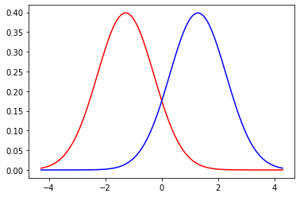

```python
import matplotlib.pyplot as plt
import numpy as np
import scipy.stats as stats
import math

%matplotlib inline

mu_adj_f1 = 1.28155
mu0_f1 = -mu_adj_f1
mu1_f1 = mu_adj_f1
var0_f1 = 1
var1_f1 = 1
sigma0_f1 = math.sqrt(var0_f1)
sigma1_f1 = math.sqrt(var1_f1)
x = np.linspace(min(mu0_f1 - 3*sigma0_f1, mu1_f1-3*sigma1_f1), max(mu0_f1 + 3*sigma0_f1, mu1_f1 + 3*sigma1_f1), 100)
plt.plot(x, stats.norm.pdf(x, mu0_f1, sigma0_f1), c = "red")
plt.plot(x, stats.norm.pdf(x, mu1_f1, sigma1_f1), c = "blue")
plt.show()
```

```python
# We want the blue curve to have it's 10th percentile at x=0.
stats.norm.cdf(0, mu1_f1, sigma1_f1)
```

```
0.10000027475074158
```

```python
print("Samples from each distribution should be assigned correctly with probability approximately 0.9.")
class_0_f_1 = np.random.normal(mu0_f1, sigma0_f1, 10000)
class_1_f_1 = np.random.normal(mu1_f1, sigma1_f1, 10000)
print(np.mean(stats.norm.pdf(class_0_f_1, mu0_f1, sigma0_f1) > stats.norm.pdf(class_0_f_1, mu1_f1, sigma1_f1)))
print(np.mean(stats.norm.pdf(class_1_f_1, mu0_f1, sigma0_f1) < stats.norm.pdf(class_1_f_1, mu1_f1, sigma1_f1)))
```

```
Samples from each distribution should be assigned correctly with probability approximately 0.9.
0.902
0.8993
```

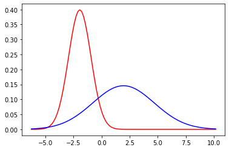

```python
# This is pretty darn close.
mu_adj_f2 = 1.94745
mu0_f2 = -mu_adj_f2
mu1_f2 = mu_adj_f2
var0_f2 = 1
var1_f2 = 7.5
sigma0_f2 = math.sqrt(var0_f2)
sigma1_f2 = math.sqrt(var1_f2)
x = np.linspace(min(mu0_f2 - 3*sigma0_f2, mu1_f2-3*sigma1_f2), max(mu0_f2 + 3*sigma0_f2, mu1_f2 + 3*sigma1_f2), 100)
plt.plot(x, stats.norm.pdf(x, mu0_f2, sigma0_f2), c = "red")
plt.plot(x, stats.norm.pdf(x, mu1_f2, sigma1_f2), c = "blue")
plt.show()
```

```python
# No longer matching up at x = 0 to facilitate easier class conditional definitions.
# print("The 95th percentile (red) should match the 20th percentile (blue) with approximately the same pdf value, all at x=0.")
# print(stats.norm.cdf(0, mu0_f2, sigma0_f2))
# print(stats.norm.cdf(0, mu1_f2, sigma1_f2))
# print(stats.norm.pdf(0, mu0_f2, sigma0_f2))
# print(stats.norm.pdf(0, mu1_f2, sigma1_f2))
```

```python
print("Samples from each distribution should be assigned correctly with probability approximately 0.95 and 0.8 for classes 0 and 1, respectively.")
class_0_f_2 = np.random.normal(mu0_f2, sigma0_f2, 10000)
class_1_f_2 = np.random.normal(mu1_f2, sigma1_f2, 10000)
print(np.mean(stats.norm.pdf(class_0_f_2, mu0_f2, sigma0_f2) > stats.norm.pdf(class_0_f_2, mu1_f2, sigma1_f2)))
print(np.mean(stats.norm.pdf(class_1_f_2, mu0_f2, sigma0_f2) < stats.norm.pdf(class_1_f_2, mu1_f2, sigma1_f2)))
```

```
Samples from each distribution should be assigned correctly with probability approximately 0.95 and 0.8 for classes 0 and 1, respectively.
0.9467
0.7975
```

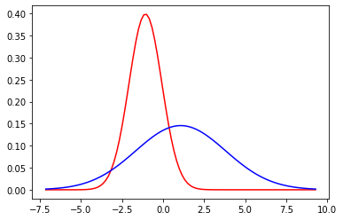

```python
# Feature 3 is tough.
# This attempt go to 95/75 with two 0-mean gaussians.
# mu0_adj_f3 = 0
# mu1_adj_f3 = 0
# mu0_f3 = 0 - mu0_adj_f3
# mu1_f3 = 0 + mu1_adj_f3
# var0_f3 = 1
# var1_f3 = 36
mu_adj_f3 = 1.07245
mu0_f3 = -mu_adj_f3
mu1_f3 = mu_adj_f3
var0_f3 = 1
var1_f3 = 7.5
sigma0_f3 = math.sqrt(var0_f3)
sigma1_f3 = math.sqrt(var1_f3)
x = np.linspace(min(mu0_f3 - 3*sigma0_f3, mu1_f3-3*sigma1_f3), max(mu0_f3 + 3*sigma0_f3, mu1_f3 + 3*sigma1_f3), 100)
plt.plot(x, stats.norm.pdf(x, mu0_f3, sigma0_f3), c = "red")
plt.plot(x, stats.norm.pdf(x, mu1_f3, sigma1_f3), c = "blue")
plt.show()
```

```python
# No longer requiring things to line up at x = 0 to facilitate easier class conditional definitions.
# print(stats.norm.cdf(0, mu0_f3, sigma0_f3))
# print(stats.norm.cdf(0, mu1_f3, sigma1_f3))
# print(stats.norm.pdf(0, mu0_f3, sigma0_f3))
# print(stats.norm.pdf(0, mu1_f3, sigma1_f3))
```

```python
# It's hard to say what makes feature 3 valuable.  By itself it is the worst single
# feature.  What makes it interesting is the utility it brings to a pair of features
# by being the best at detecting class 0, even if that comes at a price of lower
# sensitivity for class 1.
print("Samples from each distribution should be assigned correctly with probability approximately 0.99 and 0.71 for classes 0 and 1, respectively.  We can't reach those numbers, so we'll do the best we can such that feature 3's class 0 sensitivity is significantly greater than its feature 1 sensitivity.")
class_0_f_3 = np.random.normal(mu0_f3, sigma0_f3, 10000)
class_1_f_3 = np.random.normal(mu1_f3, sigma1_f3, 10000)
print(np.mean(stats.norm.pdf(class_0_f_3, mu0_f3, sigma0_f3) > stats.norm.pdf(class_0_f_3, mu1_f3, sigma1_f3)))
print(np.mean(stats.norm.pdf(class_1_f_3, mu0_f3, sigma0_f3) < stats.norm.pdf(class_1_f_3, mu1_f3, sigma1_f3)))
# print(np.mean(stats.norm.pdf(class_0_f_3, mu0_f3, sigma0_f3) > stats.norm.pdf(class_0_f_3, mu1_f3, sigma1_f3)) - np.mean(stats.norm.pdf(class_1_f_3, mu0_f3, sigma0_f3) < stats.norm.pdf(class_1_f_3, mu1_f3, sigma1_f3)))
```

```
Samples from each distribution should be assigned correctly with probability approximately 0.99 and 0.71 for classes 0 and 1, respectively.  We can't reach those numbers, so we'll do the best we can such that feature 3's class 0 sensitivity is significantly greater than its feature 1 sensitivity.
0.9122
0.6553
```

```python
import plotly.graph_objects as go
import numpy as np

fig = plt.figure()

samples_per_class = 100

class_0_f_1 = np.random.normal(mu0_f1, sigma0_f1, samples_per_class)
class_1_f_1 = np.random.normal(mu1_f1, sigma1_f1, samples_per_class)
class_0_f_2 = np.random.normal(mu0_f2, sigma0_f2, samples_per_class)
class_1_f_2 = np.random.normal(mu1_f2, sigma1_f2, samples_per_class)
class_0_f_3 = np.random.normal(mu0_f3, sigma0_f3, samples_per_class)
class_1_f_3 = np.random.normal(mu1_f3, sigma1_f3, samples_per_class)

F1 = np.concatenate((class_0_f_1, class_1_f_1))
F2 = np.concatenate((class_0_f_2, class_1_f_2))
F3 = np.concatenate((class_0_f_3, class_1_f_3))
c = np.concatenate((np.zeros(len(class_0_f_1)), np.ones(len(class_1_f_1))))

fig = go.Figure(data=[go.Scatter3d(x=F1, y=F2, z=F3,
                                   mode='markers',
    marker=dict(
        size=12,
        color=c,                # set color to an array/list of desired values
        colorscale='Viridis',   # choose a colorscale
        opacity=0.8
    ))])

fig.update_layout(scene = dict(
                    xaxis_title='F1',
                    yaxis_title='F2',
                    zaxis_title='F3'),
                    width=700,
                    margin=dict(r=20, b=10, l=10, t=10))

fig.show()
```

[interactive chart not shown]

### Gaussian Example Feature Importance Calculations

Let's try to calculate some of the same values we did above for the discrete example.

Here are the two class-conditional distributions we just created ($i \in \{0,1\}$):

$$f_i = f(x|Y=i) = \mathrm{N}\left( \mu = \begin{bmatrix} -1.28155 + 2.5631i \\ -1.94745 + 3.89492i \\ -1.07245 + 2.1449i \end{bmatrix}, \; \Sigma = \begin{bmatrix} 1 & 0 & 0 \\ 0 & 1 + 6.5i & 0 \\ 0 & 0 & 1 + 6.5i \end{bmatrix} \right)$$

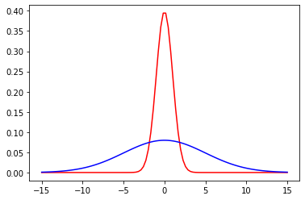

```
0.9325
0.7158
0.2167
```

```python
# We could also make all class-conditional distributions centered with
# zero mean and varying covariance matrices.  We can't get exactly the
# same probabilities as the discrete DGL example, but it could be close
# enough if we use the Toussaint hints for constructing an example.

# The main connection to the DGL example would be the similarity in
# reasons for predicting class 0 (i.e., all features need to be nearly 0);
# similarly, in the discrete case, any feature equaling 1 (or being large in the
# gaussian case) may be enough to predict class 1.  Two such features is a sure
# bet for class 1.

# Here's what that could look like for feature 3.

mu_adj_f3 = 0
mu0_f3 = -mu_adj_f3
mu1_f3 = mu_adj_f3
var0_f3 = 1
var1_f3 = 25
sigma0_f3 = math.sqrt(var0_f3)
sigma1_f3 = math.sqrt(var1_f3)
x = np.linspace(min(mu0_f3 - 3*sigma0_f3, mu1_f3-3*sigma1_f3), max(mu0_f3 + 3*sigma0_f3, mu1_f3 + 3*sigma1_f3), 100)
plt.plot(x, stats.norm.pdf(x, mu0_f3, sigma0_f3), c = "red")
plt.plot(x, stats.norm.pdf(x, mu1_f3, sigma1_f3), c = "blue")
plt.show()

class_0_f_3 = np.random.normal(mu0_f3, sigma0_f3, 10000)
class_1_f_3 = np.random.normal(mu1_f3, sigma1_f3, 10000)
print(np.mean(stats.norm.pdf(class_0_f_3, mu0_f3, sigma0_f3) > stats.norm.pdf(class_0_f_3, mu1_f3, sigma1_f3)))
print(np.mean(stats.norm.pdf(class_1_f_3, mu0_f3, sigma0_f3) < stats.norm.pdf(class_1_f_3, mu1_f3, sigma1_f3)))
print(np.mean(stats.norm.pdf(class_0_f_3, mu0_f3, sigma0_f3) > stats.norm.pdf(class_0_f_3, mu1_f3, sigma1_f3)) - np.mean(stats.norm.pdf(class_1_f_3, mu0_f3, sigma0_f3) < stats.norm.pdf(class_1_f_3, mu1_f3, sigma1_f3)))
```